# Tugas Praktikum Pertemuan 5

Nizar Hermawan (G1401231054)

2025-09-25

# Library

```r
library(ggplot2)
library(tsibble)
library(tseries)
library(MASS)
```

# Import Data

```r
datacuaca <- read.csv("C:/Users/Nizar/Downloads/Documents/Data Cuaca Kelompok 2 MPDW.csv")
datacuaca2 <- datacuaca[301:400, c("date", "VPdef")]
datacuaca2
```

```
##               date VPdef
## 301  1/3/2020 2:10  0.99
## 302  1/3/2020 2:20  0.93
## 303  1/3/2020 2:30  0.91
## 304  1/3/2020 2:40  0.88
## 305  1/3/2020 2:50  0.93
## 306  1/3/2020 3:00  0.92
## 307  1/3/2020 3:10  1.06
## 308  1/3/2020 3:20  1.10
## 309  1/3/2020 3:30  1.19
## 310  1/3/2020 3:40  1.22
## 311  1/3/2020 3:50  1.26
## 312  1/3/2020 4:00  1.26
## 313  1/3/2020 4:10  1.16
## 314  1/3/2020 4:20  1.15
```

[output cut: 86 more lines]

# Ubah jadi data TS

```r
data.ts <- ts(datacuaca2$VPdef)
```

# Plot Data TS

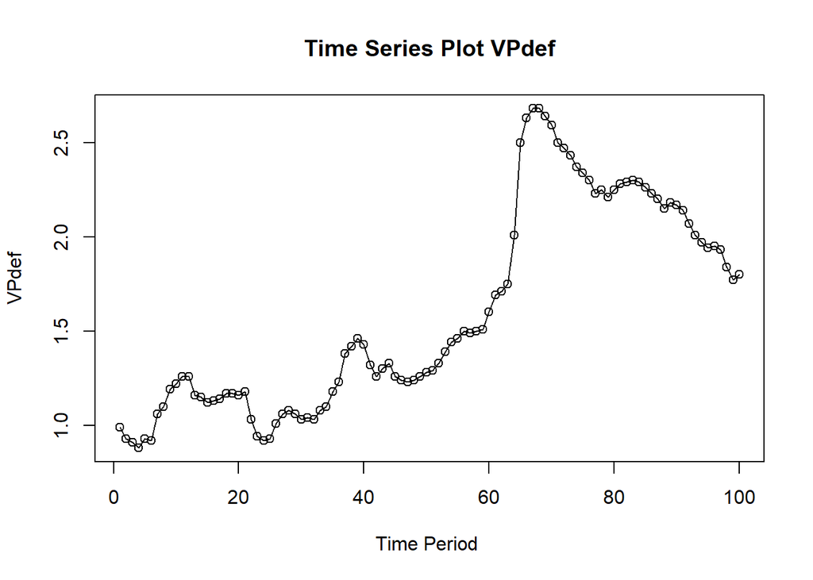

```r
ts.plot(data.ts, xlab="Time Period ", ylab="VPdef",
        main = "Time Series Plot VPdef")
points(data.ts)
```

# Plot ACF

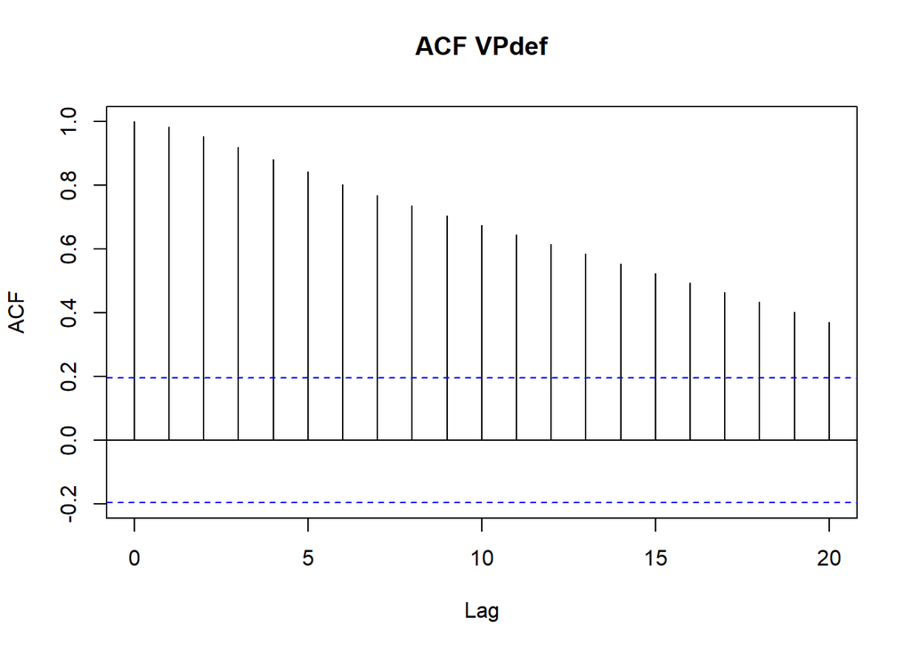

```r
acf(data.ts, main="ACF VPdef")
```

# Uji ADF

```r
adf.test(data.ts)
```

```
##
##  Augmented Dickey-Fuller Test
##
## data:  data.ts
## Dickey-Fuller = -1.9754, Lag order = 4, p-value = 0.5868
## alternative hypothesis: stationary
```

$H_0$ : Data tidak stasioner dalam rataan

$H_1$ : Data stasioner dalam rataan

Berdasarkan uji ADF tersebut, didapat *p-value* sebesar 0.5868 yang lebih besar dari taraf nyata 5% dan menandakan bahwa data tidak stasioner dalam rataan. Hal ini sesuai dengan hasil eksplorasi menggunakan plot time series dan plot ACF

# Plot Box-Cox

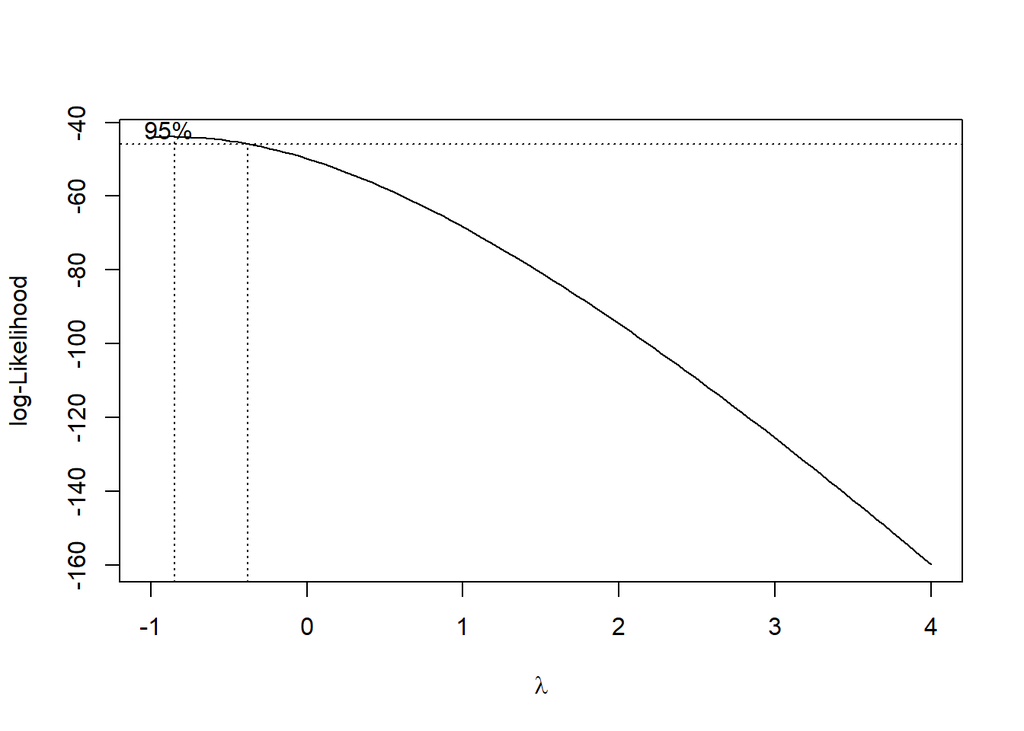

```r
index = seq(301:400)
b = boxcox(data.ts~index, lambda = seq(-1,4,by=1))
```

```r
#Nilai Rounded Lambda
lambda = b$x[which.max(b$y)]
lambda
```

```
## [1] -0.8484848
```

```r
#SK
b$x[b$y > max(b$y) - 1/2 * qchisq(.95,1)]
```

```
##  [1] -1.0000000 -0.9494949 -0.8989899 -0.8484848 -0.7979798 -0.7474747
##  [7] -0.6969697 -0.6464646 -0.5959596 -0.5454545 -0.4949495 -0.4444444
## [13] -0.3939394
```

Berdasarkan plot Box-Cox, diperoleh nilai rounded value ($\lambda$) optimum sebesar -0.85 dengan selang kepercayaan 95% yaitu (-1.00, -0.39). Karena selang tersebut tidak memuat nilai satu, maka dapat disimpulkan bahwa data belum stasioner dalam ragam sehingga perlu dilakukan transformasi Box-Cox dengan $\lambda = -0.85$.

## Partisi data

### Data Train

```r
data.ts1 <- data.ts[1:80] |> ts()
mean(data.ts1)
```

```
## [1] 1.47375
```

```r
var(data.ts1)
```

```
## [1] 0.2847756
```

#### Plot Time Series Data Train

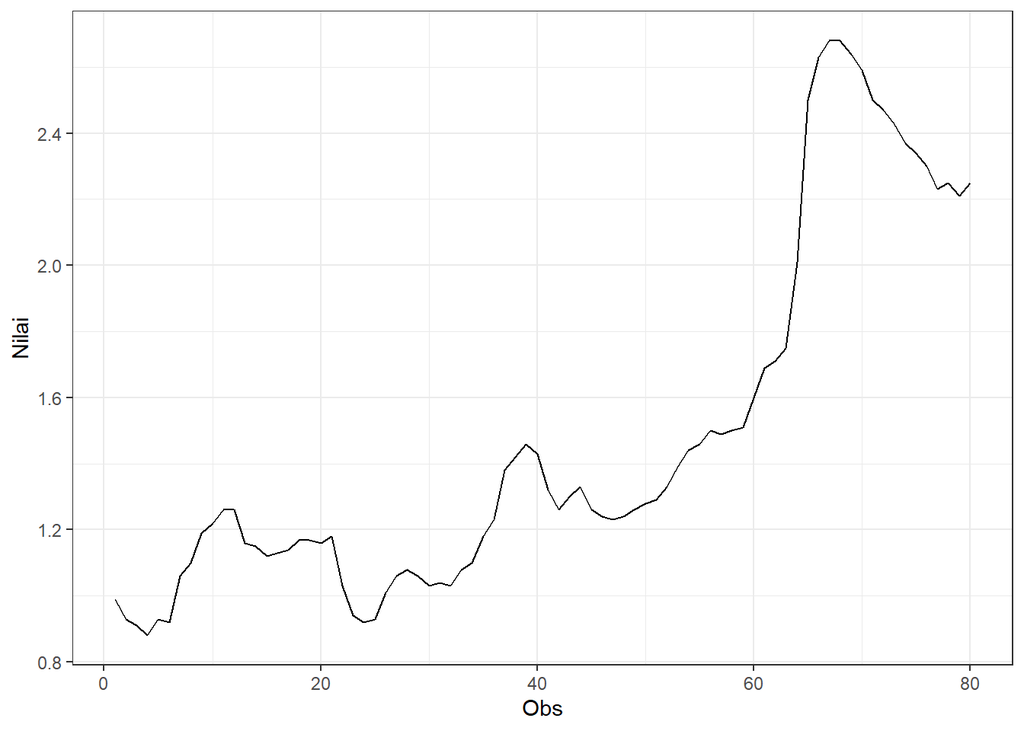

```r
data.ts1 |> as_tsibble() |>
  ggplot(aes(x = index, y = value)) +
  geom_line()+theme_bw() +
  xlab("Obs") + ylab("Nilai")
```

#### Plot ACF Data Train

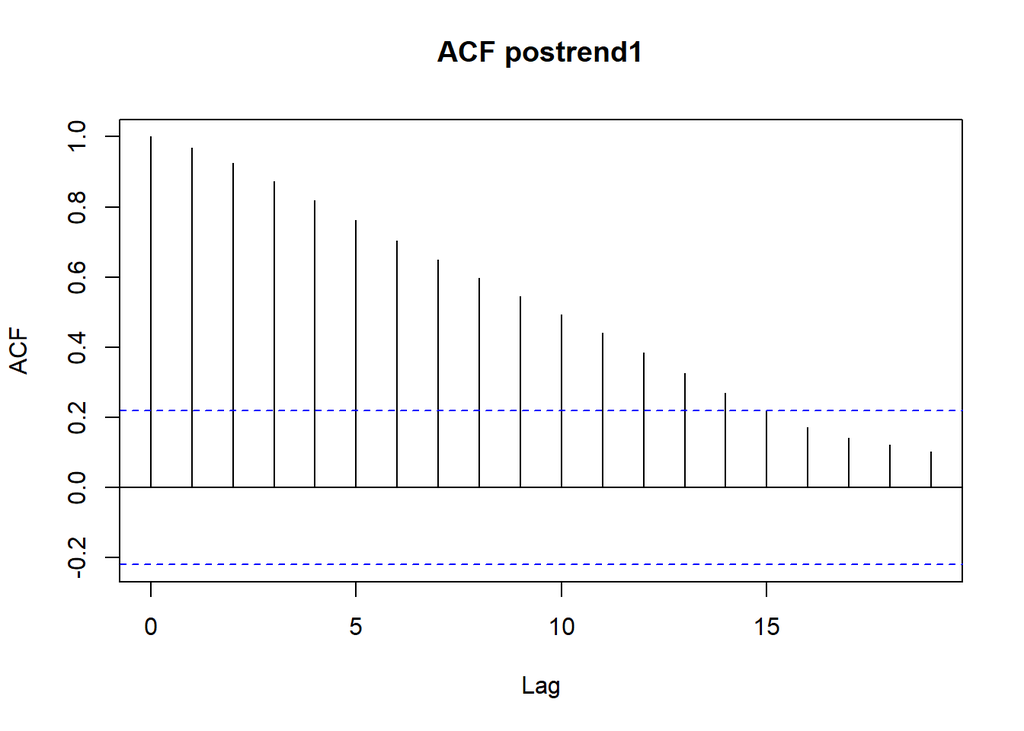

```r
acf(data.ts1, main="ACF postrend1")
```

#### Uji ADF Data Train

```r
adf.test(data.ts1)
```

```
##
##  Augmented Dickey-Fuller Test
##
## data:  data.ts1
## Dickey-Fuller = -2.2715, Lag order = 4, p-value = 0.4646
## alternative hypothesis: stationary
```

#### Plot Box-Cox Data Train

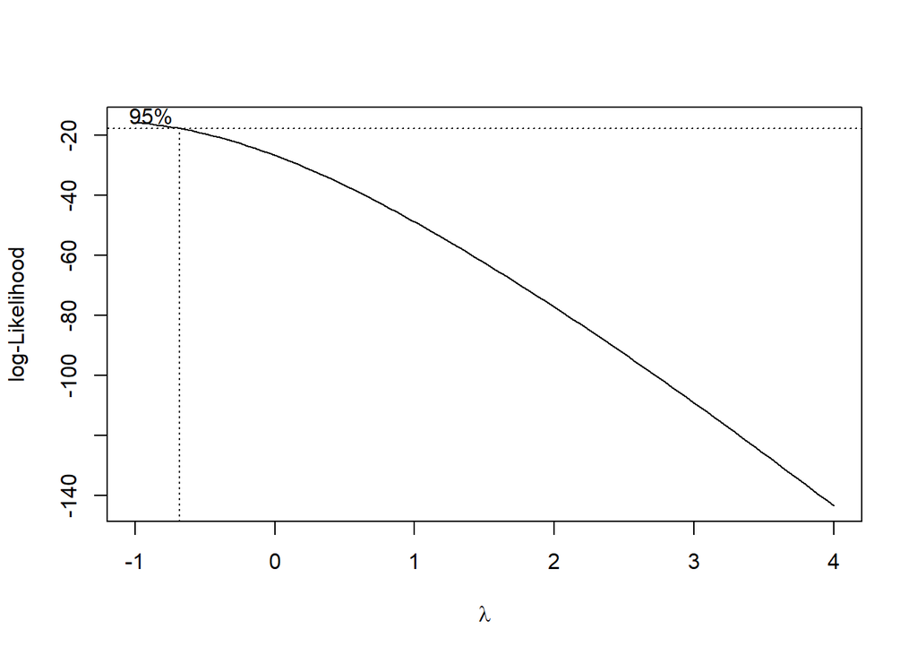

```r
index1 = seq(1:80)
b1 = boxcox(data.ts1~index1, lambda = seq(-1,4,by=1))
```

```r
#Nilai Rounded Lambda
lambda1 = b1$x[which.max(b1$y)]
lambda1
```

```
## [1] -1
```

```r
#SK
b1$x[b1$y > max(b1$y) - 1/2 * qchisq(.95,1)]
```

```
## [1] -1.0000000 -0.9494949 -0.8989899 -0.8484848 -0.7979798 -0.7474747 -0.6969697
```

### Data Test

```r
data.ts2 <- data.ts[81:100] |> ts()
mean(data.ts2)
```

```
## [1] 2.0885
```

```r
var(data.ts2)
```

```
## [1] 0.03048711
```

#### Plot Time Series Data Test

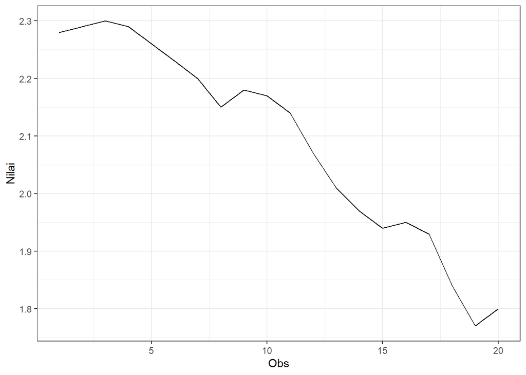

```r
data.ts2 |> as_tsibble() |>
  ggplot(aes(x = index, y = value)) +
  geom_line()+theme_bw() +
  xlab("Obs") + ylab("Nilai")
```

#### Plot ACF Data Test

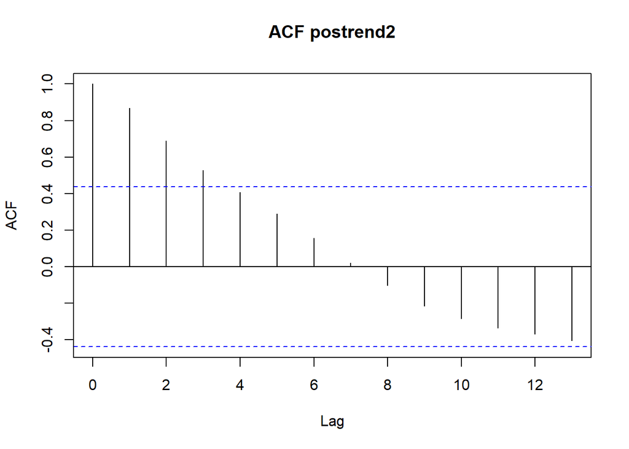

```r
acf(data.ts2, main="ACF postrend2")
```

#### Uji ADF Data Test

```r
adf.test(data.ts2)
```

```
##
##  Augmented Dickey-Fuller Test
##
## data:  data.ts2
## Dickey-Fuller = -2.2894, Lag order = 2, p-value = 0.4621
## alternative hypothesis: stationary
```

#### Plot Box-Cox Data Test

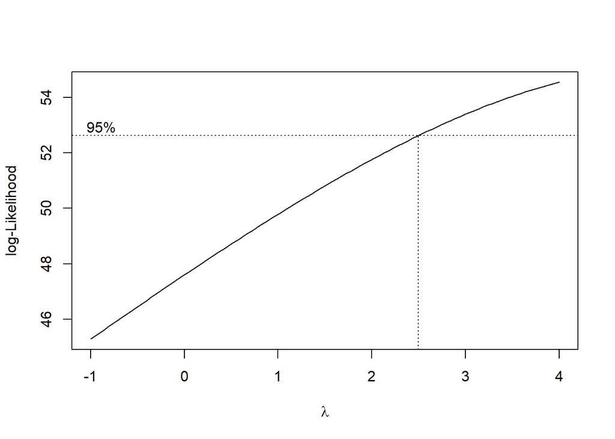

```r
index2 = seq(81:100)
b2 = boxcox(data.ts2~index2, lambda = seq(-1,4,by=1))
```

```r
#Nilai Rounded Lambda
lambda2 = b2$x[which.max(b2$y)]
lambda2
```

```
## [1] 4
```

```r
#SK
b2$x[b2$y > max(b2$y) - 1/2 * qchisq(.95,1)]
```

```
##  [1] 2.535354 2.585859 2.636364 2.686869 2.737374 2.787879 2.838384 2.888889
##  [9] 2.939394 2.989899 3.040404 3.090909 3.141414 3.191919 3.242424 3.292929
## [17] 3.343434 3.393939 3.444444 3.494949 3.545455 3.595960 3.646465 3.696970
## [25] 3.747475 3.797980 3.848485 3.898990 3.949495 4.000000
```

# Penanganan

## Transformasi Box-Cox

```r
library(forecast)
```

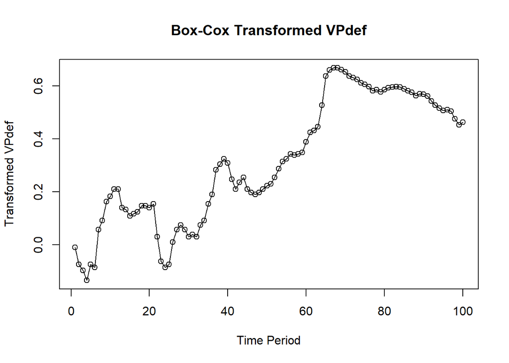

```r
# Transformasi Box-Cox dengan lambda = -0.85
data.bc <- BoxCox(data.ts, lambda = -0.85)

# Plot hasil transformasi
ts.plot(data.bc, xlab = "Time Period", ylab = "Transformed VPdef",
        main = "Box-Cox Transformed VPdef")
points(data.bc)
```

## Plot Setelah Transformasi Box-Cox

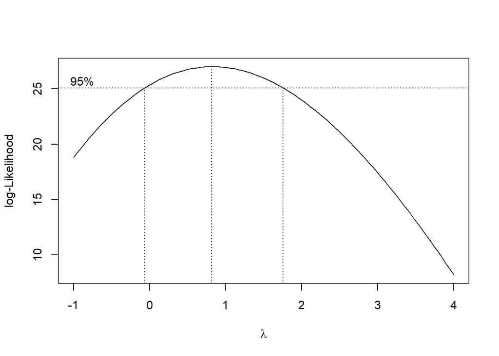

```r
#### Plot Setelah Transformasi
# Buat index waktu
index <- seq_along(data.bc)

# Tambahkan konstanta biar semua nilai positif
data.bc.pos <- data.bc - min(data.bc) + 1

# Model regresi dummy
model_bc <- lm(data.bc.pos ~ index)

# Plot Box-Cox
b <- boxcox(model_bc, lambda = seq(-1, 4, by = 0.1))
```

```r
# Nilai lambda optimum
lambda_bc <- b$x[which.max(b$y)]
lambda_bc
```

```
## [1] 0.8181818
```

```r
# Selang kepercayaan 95%
b$x[b$y > max(b$y) - 1/2 * qchisq(.95,1)]
```

```
##  [1] -0.04040404  0.01010101  0.06060606  0.11111111  0.16161616  0.21212121
##  [7]  0.26262626  0.31313131  0.36363636  0.41414141  0.46464646  0.51515152
## [13]  0.56565657  0.61616162  0.66666667  0.71717172  0.76767677  0.81818182
## [19]  0.86868687  0.91919192  0.96969697  1.02020202  1.07070707  1.12121212
## [25]  1.17171717  1.22222222  1.27272727  1.32323232  1.37373737  1.42424242
## [31]  1.47474747  1.52525253  1.57575758  1.62626263  1.67676768  1.72727273
```

Karena selang ini memuat nilai 1, maka bisa dikatakan bahwa data hasil transformasi Box-Cox sudah stasioner dalam ragam

## Diferensiasi

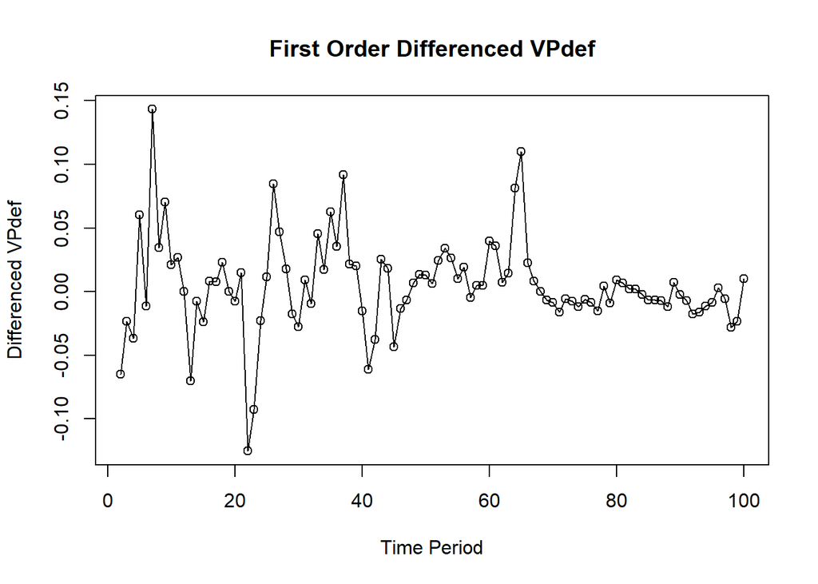

```r
# Diferensiasi orde 1
data.diff1 <- diff(data.bc, differences = 1)
# Plot hasil diferensiasi
ts.plot(data.diff1, xlab = "Time Period", ylab = "Differenced VPdef",
        main = "First Order Differenced VPdef")
points(data.diff1)
```

## Plot ACF hasil diferensiasi

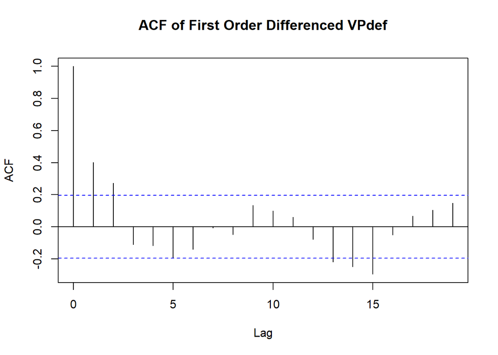

```r
acf(data.diff1, main = "ACF of First Order Differenced VPdef")
```

Setelah dilakukan differencing, pola ACF sudah terlihat cut-off) dan sebagian besar lag berada dalam batas kepercayaan. Ini menandakan tren sudah teratasi.

## Uji ADF hasil diferensiasi

```r
adf.test(data.diff1)
```

```
##
##  Augmented Dickey-Fuller Test
##
## data:  data.diff1
## Dickey-Fuller = -4.7513, Lag order = 4, p-value = 0.01
## alternative hypothesis: stationary
```

$H_0$ : Data tidak stasioner dalam rataan $H_1$ : Data stasioner dalam rataan

Berdasarkan uji ADF tersebut, didapat *p-value* sebesar 0.01 yang lebih kecil dari taraf nyata 5% dan menandakan bahwa data stasioner dalam rataan. Hal ini sesuai dengan hasil eksplorasi menggunakan plot time series dan plot ACF

# Kesimpulan

Berdasarkan hasil analisis, dapat disimpulkan bahwa data VPdef awalnya tidak stasioner dalam rataan dan ragam. Setelah dilakukan transformasi Box-Cox dengan λ = -0.85, data menjadi stasioner dalam ragam. Selanjutnya, dengan melakukan diferensiasi 1 kali, data menjadi stasioner dalam rataan. Hal ini didukung oleh hasil uji ADF yang menunjukkan p-value < 0.05 setelah diferensiasi, serta pola ACF yang menunjukkan cut-off setelah diferensiasi.